# Spain COVID-19 Vaccine Rollout

IllicitDavid Jackson

2/7/2021 1:15 PM/EST

### Our World In Data: http://ourworldindata.org

### Definitions:

- **total_vaccinations**, Total number of COVID-19 vaccination doses administered.
- **people_vaccinated**, Total number of people who received at least one vaccine dose.
- **people_fully_vaccinated**,Total number of people who received all doses prescribed by the vaccination protocol.
- **new_vaccinations**, New COVID-19 vaccination doses administered (only calculated for consecutive days)
- **new_vaccinations_smoothed**, New COVID-19 vaccination doses administered (7-day smoothed). For countries that don’t report vaccination data on a daily basis, we assume that vaccination changed equally on a daily basis over any periods in which no data was reported. This produces a complete series of daily figures, which is then averaged over a rolling 7-day window.
- **total_vaccinations_per_hundred**, Total number of COVID-19 vaccination doses administered per 100 people in the total population.
- **people_vaccinated_per_hundred**, Total number of people who received at least one vaccine dose per 100 people in the total population.
- **people_fully_vaccinated_per_hundred**, Total number of people who received all doses prescribed by the vaccination protocol per 100 people in the total population.
- **new_vaccinations_smoothed_per_million**, New COVID-19 vaccination doses administered (7-day smoothed) per 1,000,000 people in the total population.

### Individual Plot for Each Type of Vaccination

#### total_vaccinations

*Total number of COVID-19 vaccination doses administered.

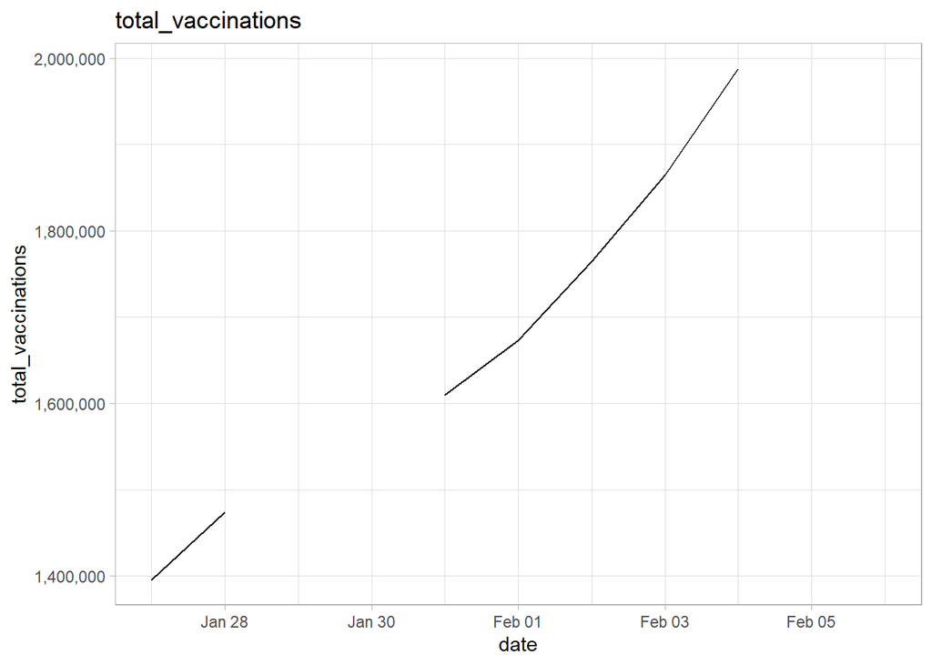

#### people_vaccinated

- Total number of people who received at least one vaccine dose.

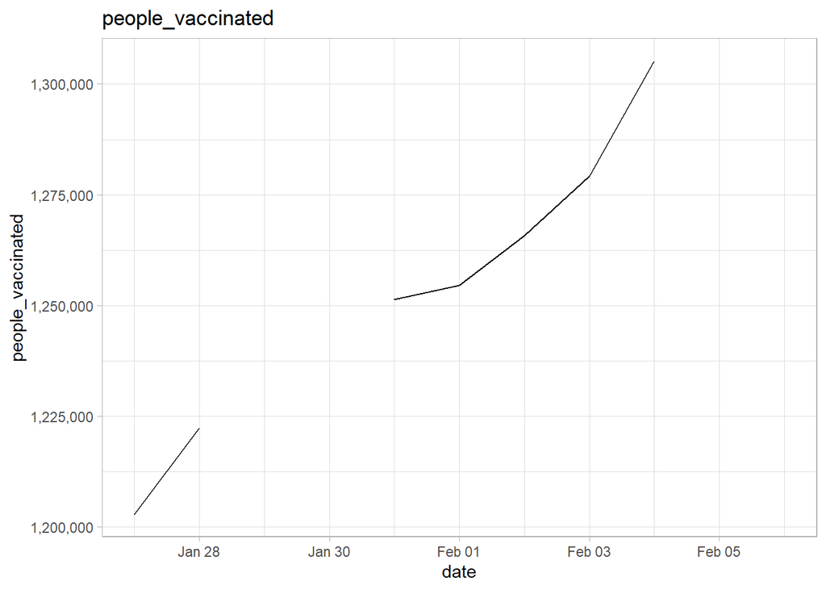

#### people_fully_vaccinated

- Total number of people who received all doses prescribed by the vaccination protocol.

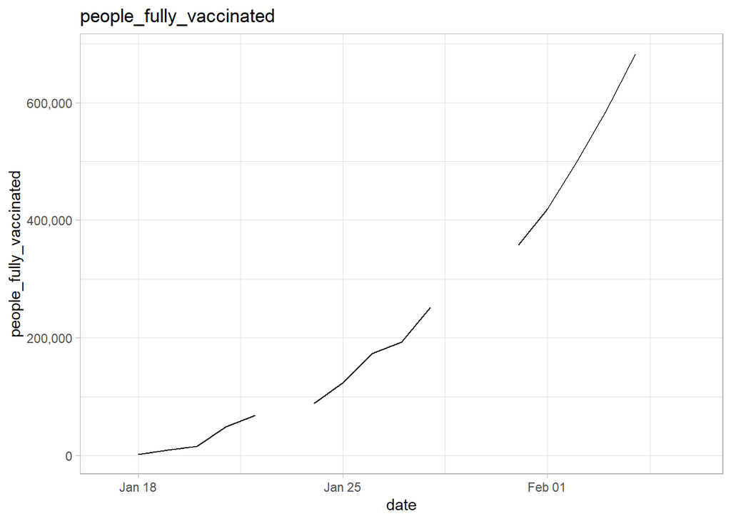

#### new_vaccinations

- New COVID-19 vaccination doses administered (only calculated for consecutive days).

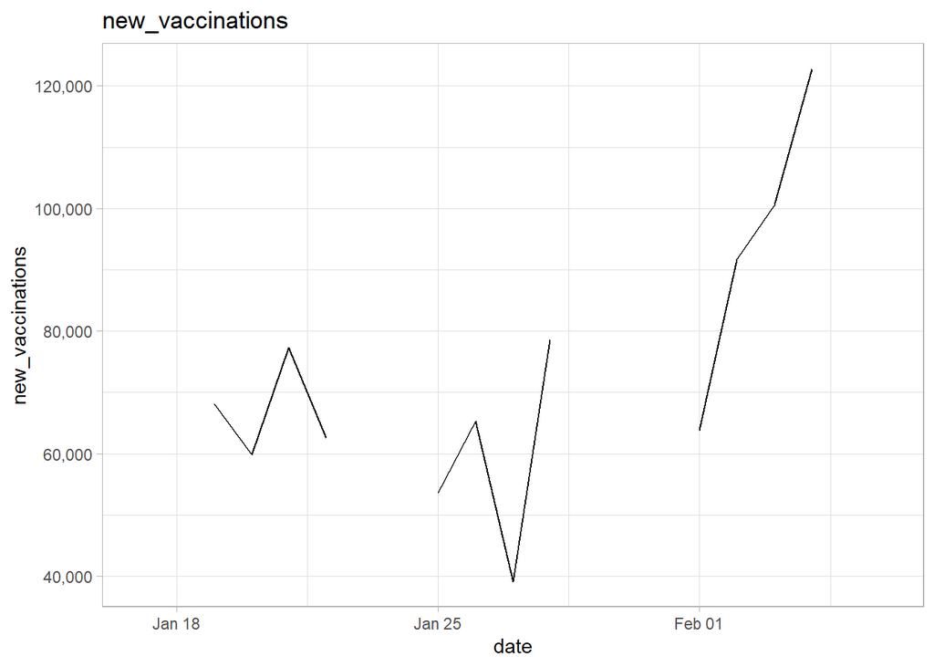

#### new_vaccinations_smoothed

- New COVID-19 vaccination doses administered (7-day smoothed). For countries that don’t report vaccination data on a daily basis, we assume that vaccination changed equally on a daily basis over any periods in which no data was reported. This produces a complete series of daily figures, which is then averaged over a rolling 7-day window.

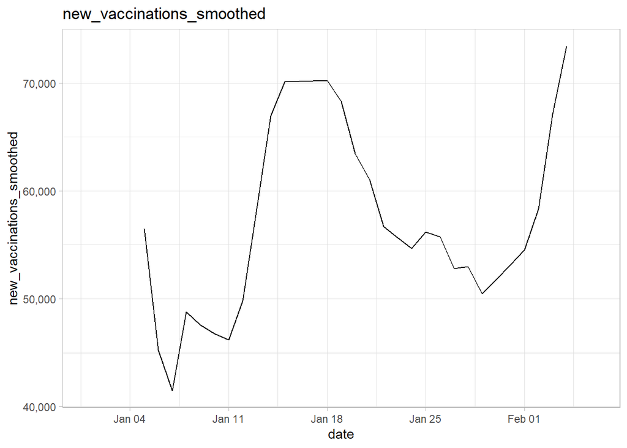

#### total_vaccinations_per_hundred

- Total number of COVID-19 vaccination doses administered per 100 people in the total population.

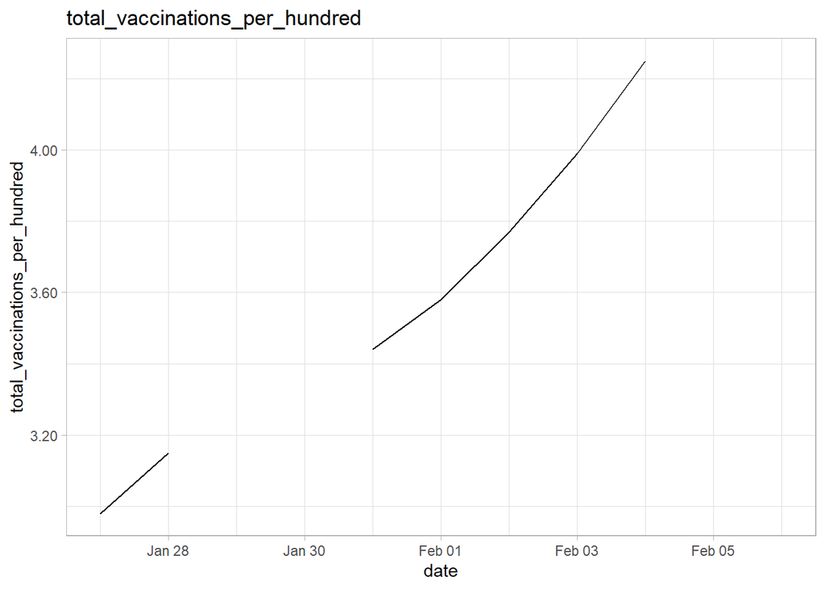

#### people_vaccinated_per_hundred

- Total number of people who received at least one vaccine dose per 100 people in the total population.

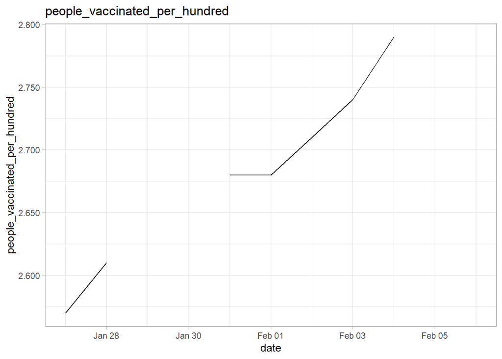

#### people_fully_vaccinated_per_hundred

- Total number of people who received all doses prescribed by the vaccination protocol per 100 people in the total population.

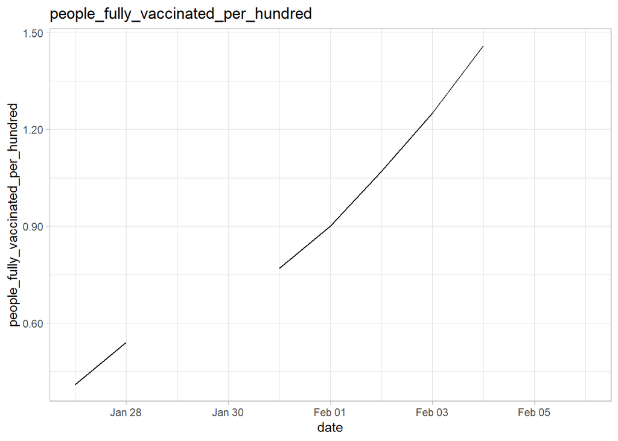

#### new_vaccinations_smoothed_per_million

- New COVID-19 vaccination doses administered (7-day smoothed) per 1,000,000 people in the total population.

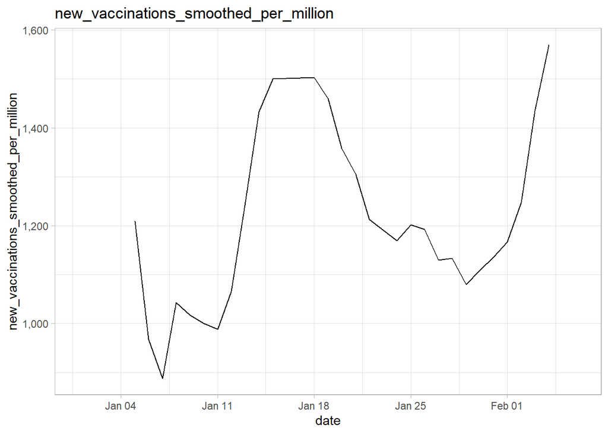